# Neural Networks

```r
# Classification vs Clustering

#Both *Classification* and *Clustering* are method of pattern identification. The main difference between the two is that:

#- the first is a form of `Supervised learning`, meaning that the labels are predefined, already assigned; it is used to predict whether or not any new data point belongs to one of the original group of labels.
#- the second is instead a form of `Unsupervised learning`, meaning that identify itself similarities among objects dividing them into groups, which are known as `clusters`.

## Neural networks
```

`Neural Network` (also called ’artificial neural networks or simulated neural networks) is an algorithm that try to mimic the brain.

It have been widely used in 80s and early 90s, its popularity diminisced in late 90s, but recently is again widely popular and used in many applications.

### suitable areas of application

ANNs are often used to classify and cluster data at a high velocity. i.e. speech recognition or image recognition.

The most famous example is `Google’s search algorithm`.

### How does (ANNs) works

Essentially they are composed by node layers containing an input layer, one or more hidden layers, and an output layer.

each node simulate an artificial neuron, it has a `weight` and a `threshold` and it is connected to the nodes of the next layer.

If the output of any specific node is higher than the threshold value, than it send data to the next node.

We can think of each individual node as its own linear regression model, composed of input data, weights, a threshold and an output.

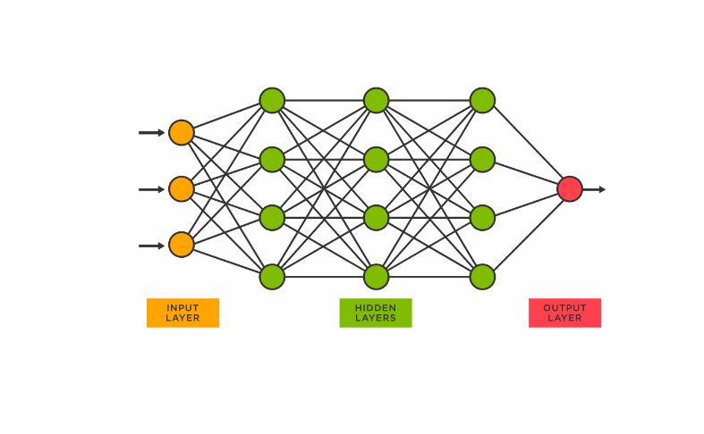

All inputs are then multiplied by their respective weights and then summed. Then, the output is passed through an activation function, which determines the output.

$$g(w_1x_1 + w_2x_2 +...+ w_ix_i +
threshould)$$

if
$$\sum_{i}{w_ix_i} >
threshould$$
, than the node is activated and the information pass.

For example:

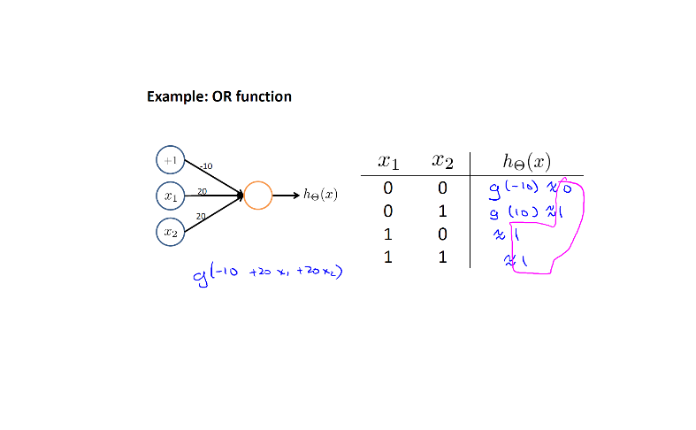

```r
library(magick)

img <- magick::image_read('ann_2.png')
plot(img) #www.coursera.com
```

### Strengths

- Use large datasets
- Non-linear and flexible
- Fast

### Weaknesses

- they can learn from training data, so they requires a huge amount of data
- they can become too complex
- high computational requirements